```python
# Importing all the necessary libraries

import numpy as np
import pandas as pd
import matplotlib.pyplot as plt
%matplotlib inline
import seaborn as sns
from sklearn import preprocessing
from sklearn.model_selection import train_test_split, cross_val_score
from sklearn.tree import DecisionTreeClassifier
from sklearn import metrics
from scipy.stats import zscore
from sklearn.metrics import classification_report, confusion_matrix
from sklearn import tree
from sklearn.ensemble import BaggingClassifier
from sklearn.ensemble import AdaBoostClassifier
from sklearn.ensemble import GradientBoostingClassifier
from sklearn.ensemble import RandomForestClassifier
import pickle
```

# 1. Import and warehouse data: [ Score: 5 point ]

• Import all the given datasets. Explore shape and size.

• Merge all datasets onto one and explore final shape and size.

```python
# Reading the file
# Merging of datasets is not applicable for the selected file

churn = pd.read_csv('TelcomCustomer-Churn.csv')
```

```python
# Exploring the shape of the dataset

churn.shape
```

```
(7043, 21)
```

```python
# Exploring the size of the dataset

churn.size
```

```
147903
```

```python
churn.head()
```

|  | customerID | gender | SeniorCitizen | Partner | Dependents | tenure | PhoneService | MultipleLines | InternetService | OnlineSecurity | ... | DeviceProtection | TechSupport | StreamingTV | StreamingMovies | Contract | PaperlessBilling | PaymentMethod | MonthlyCharges | TotalCharges | Churn |
| --- | --- | --- | --- | --- | --- | --- | --- | --- | --- | --- | --- | --- | --- | --- | --- | --- | --- | --- | --- | --- | --- |
| 0 | 7590-VHVEG | Female | 0 | Yes | No | 1 | No | No phone service | DSL | No | ... | No | No | No | No | Month-to-month | Yes | Electronic check | 29.85 | 29.85 | No |
| 1 | 5575-GNVDE | Male | 0 | No | No | 34 | Yes | No | DSL | Yes | ... | Yes | No | No | No | One year | No | Mailed check | 56.95 | 1889.5 | No |
| 2 | 3668-QPYBK | Male | 0 | No | No | 2 | Yes | No | DSL | Yes | ... | No | No | No | No | Month-to-month | Yes | Mailed check | 53.85 | 108.15 | Yes |
| 3 | 7795-CFOCW | Male | 0 | No | No | 45 | No | No phone service | DSL | Yes | ... | Yes | Yes | No | No | One year | No | Bank transfer (automatic) | 42.30 | 1840.75 | No |
| 4 | 9237-HQITU | Female | 0 | No | No | 2 | Yes | No | Fiber optic | No | ... | No | No | No | No | Month-to-month | Yes | Electronic check | 70.70 | 151.65 | Yes |

5 rows × 21 columns

```python
churn.tail()
```

|  | customerID | gender | SeniorCitizen | Partner | Dependents | tenure | PhoneService | MultipleLines | InternetService | OnlineSecurity | ... | DeviceProtection | TechSupport | StreamingTV | StreamingMovies | Contract | PaperlessBilling | PaymentMethod | MonthlyCharges | TotalCharges | Churn |
| --- | --- | --- | --- | --- | --- | --- | --- | --- | --- | --- | --- | --- | --- | --- | --- | --- | --- | --- | --- | --- | --- |
| 7038 | 6840-RESVB | Male | 0 | Yes | Yes | 24 | Yes | Yes | DSL | Yes | ... | Yes | Yes | Yes | Yes | One year | Yes | Mailed check | 84.80 | 1990.5 | No |
| 7039 | 2234-XADUH | Female | 0 | Yes | Yes | 72 | Yes | Yes | Fiber optic | No | ... | Yes | No | Yes | Yes | One year | Yes | Credit card (automatic) | 103.20 | 7362.9 | No |
| 7040 | 4801-JZAZL | Female | 0 | Yes | Yes | 11 | No | No phone service | DSL | Yes | ... | No | No | No | No | Month-to-month | Yes | Electronic check | 29.60 | 346.45 | No |
| 7041 | 8361-LTMKD | Male | 1 | Yes | No | 4 | Yes | Yes | Fiber optic | No | ... | No | No | No | No | Month-to-month | Yes | Mailed check | 74.40 | 306.6 | Yes |
| 7042 | 3186-AJIEK | Male | 0 | No | No | 66 | Yes | No | Fiber optic | Yes | ... | Yes | Yes | Yes | Yes | Two year | Yes | Bank transfer (automatic) | 105.65 | 6844.5 | No |

5 rows × 21 columns

```python
churn.info()
```

```
<class 'pandas.core.frame.DataFrame'>
RangeIndex: 7043 entries, 0 to 7042
Data columns (total 21 columns):
 #   Column            Non-Null Count  Dtype
---  ------            --------------  -----
 0   customerID        7043 non-null   object
 1   gender            7043 non-null   object
 2   SeniorCitizen     7043 non-null   int64
 3   Partner           7043 non-null   object
 4   Dependents        7043 non-null   object
 5   tenure            7043 non-null   int64
 6   PhoneService      7043 non-null   object
 7   MultipleLines     7043 non-null   object
 8   InternetService   7043 non-null   object
 9   OnlineSecurity    7043 non-null   object
 10  OnlineBackup      7043 non-null   object
 11  DeviceProtection  7043 non-null   object
 12  TechSupport       7043 non-null   object
 13  StreamingTV       7043 non-null   object
 14  StreamingMovies   7043 non-null   object
 15  Contract          7043 non-null   object
 16  PaperlessBilling  7043 non-null   object
 17  PaymentMethod     7043 non-null   object
 18  MonthlyCharges    7043 non-null   float64
 19  TotalCharges      7043 non-null   object
 20  Churn             7043 non-null   object
dtypes: float64(1), int64(2), object(18)
memory usage: 1.1+ MB
```

Many columns are of type object i.e. strings. These need to be converted to ordinal type

# 2. Data cleansing: [ Score: 10 point ]

• Missing value treatment

• Convert categorical attributes to continuous using relevant functional knowledge

• Drop attribute/s if required using relevant functional knowledge

• Automate all the above steps

```python
# Dropping customerID column, as it is not required

churn = churn.drop(labels= ['customerID'] , axis = 1)
```

```python
churn.head()
```

|  | gender | SeniorCitizen | Partner | Dependents | tenure | PhoneService | MultipleLines | InternetService | OnlineSecurity | OnlineBackup | DeviceProtection | TechSupport | StreamingTV | StreamingMovies | Contract | PaperlessBilling | PaymentMethod | MonthlyCharges | TotalCharges | Churn |
| --- | --- | --- | --- | --- | --- | --- | --- | --- | --- | --- | --- | --- | --- | --- | --- | --- | --- | --- | --- | --- |
| 0 | Female | 0 | Yes | No | 1 | No | No phone service | DSL | No | Yes | No | No | No | No | Month-to-month | Yes | Electronic check | 29.85 | 29.85 | No |
| 1 | Male | 0 | No | No | 34 | Yes | No | DSL | Yes | No | Yes | No | No | No | One year | No | Mailed check | 56.95 | 1889.5 | No |
| 2 | Male | 0 | No | No | 2 | Yes | No | DSL | Yes | Yes | No | No | No | No | Month-to-month | Yes | Mailed check | 53.85 | 108.15 | Yes |
| 3 | Male | 0 | No | No | 45 | No | No phone service | DSL | Yes | No | Yes | Yes | No | No | One year | No | Bank transfer (automatic) | 42.30 | 1840.75 | No |
| 4 | Female | 0 | No | No | 2 | Yes | No | Fiber optic | No | No | No | No | No | No | Month-to-month | Yes | Electronic check | 70.70 | 151.65 | Yes |

```python
churn.shape
```

```
(7043, 20)
```

By exploring the data, some blank cells were observed in 'TotalCharges' column

```python
#Counting the number of blank data in 'TotalCharges' column

count = 0
for i in churn['TotalCharges']:
    if i ==' ':
        count = count+1

count
```

```
11
```

```python
churn['TotalCharges'] = churn['TotalCharges'].replace(' ',np.NaN)
```

```python
#As the number of rows with NaN (blank data) is insignifcant, they are dropped

churn.dropna(inplace=True)
```

```python
#Shape of dataframe after dropping rows with NaN (blank data)

churn.shape
```

```
(7032, 20)
```

```python
#Changing the type of 'TotalCharges' from object to float type

churn['TotalCharges'] = churn['TotalCharges'].astype('float64')
```

```python
churn.dtypes
```

```
gender               object
SeniorCitizen         int64
Partner              object
Dependents           object
tenure                int64
PhoneService         object
MultipleLines        object
InternetService      object
OnlineSecurity       object
OnlineBackup         object
DeviceProtection     object
TechSupport          object
StreamingTV          object
StreamingMovies      object
Contract             object
PaperlessBilling     object
PaymentMethod        object
MonthlyCharges      float64
TotalCharges        float64
Churn                object
dtype: object
```

```python
for feature in churn.columns: # Loop through all columns in the dataframe
    if churn[feature].dtype == 'object': # Only apply for columns with strings
        churn[feature] = pd.Categorical(churn[feature])# Change object data type to categorical data type
churn.head()
```

|  | gender | SeniorCitizen | Partner | Dependents | tenure | PhoneService | MultipleLines | InternetService | OnlineSecurity | OnlineBackup | DeviceProtection | TechSupport | StreamingTV | StreamingMovies | Contract | PaperlessBilling | PaymentMethod | MonthlyCharges | TotalCharges | Churn |
| --- | --- | --- | --- | --- | --- | --- | --- | --- | --- | --- | --- | --- | --- | --- | --- | --- | --- | --- | --- | --- |
| 0 | Female | 0 | Yes | No | 1 | No | No phone service | DSL | No | Yes | No | No | No | No | Month-to-month | Yes | Electronic check | 29.85 | 29.85 | No |
| 1 | Male | 0 | No | No | 34 | Yes | No | DSL | Yes | No | Yes | No | No | No | One year | No | Mailed check | 56.95 | 1889.50 | No |
| 2 | Male | 0 | No | No | 2 | Yes | No | DSL | Yes | Yes | No | No | No | No | Month-to-month | Yes | Mailed check | 53.85 | 108.15 | Yes |
| 3 | Male | 0 | No | No | 45 | No | No phone service | DSL | Yes | No | Yes | Yes | No | No | One year | No | Bank transfer (automatic) | 42.30 | 1840.75 | No |
| 4 | Female | 0 | No | No | 2 | Yes | No | Fiber optic | No | No | No | No | No | No | Month-to-month | Yes | Electronic check | 70.70 | 151.65 | Yes |

```python
churn.dtypes
```

```
gender              category
SeniorCitizen          int64
Partner             category
Dependents          category
tenure                 int64
PhoneService        category
MultipleLines       category
InternetService     category
OnlineSecurity      category
OnlineBackup        category
DeviceProtection    category
TechSupport         category
StreamingTV         category
StreamingMovies     category
Contract            category
PaperlessBilling    category
PaymentMethod       category
MonthlyCharges       float64
TotalCharges         float64
Churn               category
dtype: object
```

```python
#Printing the value counts of columns with object data type

for feature in churn.columns:
    if (churn[feature].dtype == 'float64' or churn[feature].dtype == 'int64'):
        continue
    else:
        print(churn[feature].value_counts(),'\n')
```

```
Male      3549
Female    3483
Name: gender, dtype: int64

No     3639
Yes    3393
Name: Partner, dtype: int64

No     4933
Yes    2099
Name: Dependents, dtype: int64

Yes    6352
No      680
Name: PhoneService, dtype: int64

No                  3385
Yes                 2967
No phone service     680
Name: MultipleLines, dtype: int64

Fiber optic    3096
DSL            2416
No             1520
Name: InternetService, dtype: int64

No                     3497
Yes                    2015
No internet service    1520
Name: OnlineSecurity, dtype: int64

No                     3087
Yes                    2425
No internet service    1520
Name: OnlineBackup, dtype: int64

No                     3094
Yes                    2418
No internet service    1520
Name: DeviceProtection, dtype: int64
```

[output cut: 19 more lines]

```
Name: Contract, dtype: int64

Yes    4168
No     2864
Name: PaperlessBilling, dtype: int64

Electronic check             2365
Mailed check                 1604
Bank transfer (automatic)    1542
Credit card (automatic)      1521
Name: PaymentMethod, dtype: int64

No     5163
Yes    1869
Name: Churn, dtype: int64
```

Replacing object data with ordinal data by replacing the data and one hot encoding methods

```python
replaceStruct = {'gender':{'Female':0, 'Male':1},
                 'Partner':{'No':0, 'Yes':1},
                 'Dependents':{'No':0, 'Yes':1},
                 'PhoneService':{'No':0, 'Yes':1},
                 'MultipleLines':{'No':0, 'Yes':1, 'No phone service':0},
                 'OnlineSecurity':{'No':0, 'Yes':1, 'No internet service':0},
                 'OnlineBackup':{'No':0, 'Yes':1, 'No internet service':0},
                 'DeviceProtection':{'No':0, 'Yes':1, 'No internet service':0},
                 'TechSupport':{'No':0, 'Yes':1, 'No internet service':0},
                 'StreamingTV':{'No':0, 'Yes':1, 'No internet service':0},
                 'StreamingMovies':{'No':0, 'Yes':1, 'No internet service':0},
                 'PaperlessBilling':{'No':0, 'Yes':1},
                 'Churn':{'No':0, 'Yes':1},
                }

oneHotCols=['InternetService', 'Contract', 'PaymentMethod']
```

```python
churn.head()
```

|  | gender | SeniorCitizen | Partner | Dependents | tenure | PhoneService | MultipleLines | InternetService | OnlineSecurity | OnlineBackup | DeviceProtection | TechSupport | StreamingTV | StreamingMovies | Contract | PaperlessBilling | PaymentMethod | MonthlyCharges | TotalCharges | Churn |
| --- | --- | --- | --- | --- | --- | --- | --- | --- | --- | --- | --- | --- | --- | --- | --- | --- | --- | --- | --- | --- |
| 0 | Female | 0 | Yes | No | 1 | No | No phone service | DSL | No | Yes | No | No | No | No | Month-to-month | Yes | Electronic check | 29.85 | 29.85 | No |
| 1 | Male | 0 | No | No | 34 | Yes | No | DSL | Yes | No | Yes | No | No | No | One year | No | Mailed check | 56.95 | 1889.50 | No |
| 2 | Male | 0 | No | No | 2 | Yes | No | DSL | Yes | Yes | No | No | No | No | Month-to-month | Yes | Mailed check | 53.85 | 108.15 | Yes |
| 3 | Male | 0 | No | No | 45 | No | No phone service | DSL | Yes | No | Yes | Yes | No | No | One year | No | Bank transfer (automatic) | 42.30 | 1840.75 | No |
| 4 | Female | 0 | No | No | 2 | Yes | No | Fiber optic | No | No | No | No | No | No | Month-to-month | Yes | Electronic check | 70.70 | 151.65 | Yes |

```python
churn=churn.replace(replaceStruct)
churn=pd.get_dummies(churn, columns=oneHotCols)
churn.head()
```

|  | gender | SeniorCitizen | Partner | Dependents | tenure | PhoneService | MultipleLines | OnlineSecurity | OnlineBackup | DeviceProtection | ... | InternetService_DSL | InternetService_Fiber optic | InternetService_No | Contract_Month-to-month | Contract_One year | Contract_Two year | PaymentMethod_Bank transfer (automatic) | PaymentMethod_Credit card (automatic) | PaymentMethod_Electronic check | PaymentMethod_Mailed check |
| --- | --- | --- | --- | --- | --- | --- | --- | --- | --- | --- | --- | --- | --- | --- | --- | --- | --- | --- | --- | --- | --- |
| 0 | 0 | 0 | 1 | 0 | 1 | 0 | 0 | 0 | 1 | 0 | ... | 1 | 0 | 0 | 1 | 0 | 0 | 0 | 0 | 1 | 0 |
| 1 | 1 | 0 | 0 | 0 | 34 | 1 | 0 | 1 | 0 | 1 | ... | 1 | 0 | 0 | 0 | 1 | 0 | 0 | 0 | 0 | 1 |
| 2 | 1 | 0 | 0 | 0 | 2 | 1 | 0 | 1 | 1 | 0 | ... | 1 | 0 | 0 | 1 | 0 | 0 | 0 | 0 | 0 | 1 |
| 3 | 1 | 0 | 0 | 0 | 45 | 0 | 0 | 1 | 0 | 1 | ... | 1 | 0 | 0 | 0 | 1 | 0 | 1 | 0 | 0 | 0 |
| 4 | 0 | 0 | 0 | 0 | 2 | 1 | 0 | 0 | 0 | 0 | ... | 0 | 1 | 0 | 1 | 0 | 0 | 0 | 0 | 1 | 0 |

5 rows × 27 columns

```python
#Checking the data type of each columns after replacing the data

churn.info()
```

```
<class 'pandas.core.frame.DataFrame'>
Int64Index: 7032 entries, 0 to 7042
Data columns (total 27 columns):
 #   Column                                   Non-Null Count  Dtype
---  ------                                   --------------  -----
 0   gender                                   7032 non-null   int64
 1   SeniorCitizen                            7032 non-null   int64
 2   Partner                                  7032 non-null   int64
 3   Dependents                               7032 non-null   int64
 4   tenure                                   7032 non-null   int64
 5   PhoneService                             7032 non-null   int64
 6   MultipleLines                            7032 non-null   int64
 7   OnlineSecurity                           7032 non-null   int64
 8   OnlineBackup                             7032 non-null   int64
 9   DeviceProtection                         7032 non-null   int64
```

[output cut: 19 more lines]

# 3. Data analysis & visualisation: [ Score: 10 point ]

• Perform detailed statistical analysis on the data.

• Perform a detailed univariate, bivariate and multivariate analysis with appropriate detailed comments after each analysis.

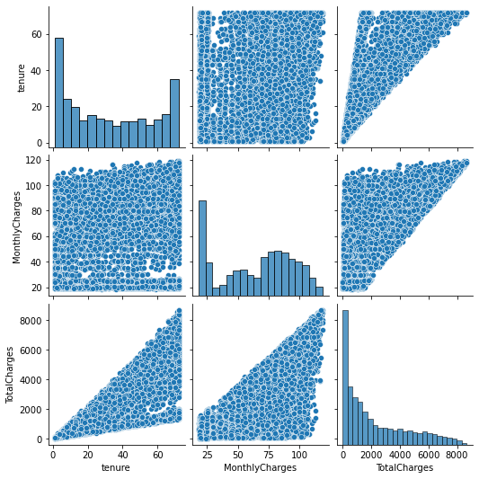

```python
sns.pairplot(churn, vars=['tenure', 'MonthlyCharges', 'TotalCharges'])
```

There is no correlation between monthly charges and tenure

Positive correlation is observed between tenure and total charges, and monthly charges and total charges

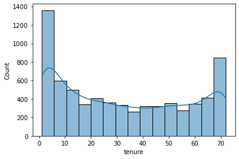

```python
sns.histplot(churn['tenure'], kde=True)
```

Large customers are new to the particular telecom company and a sizeable number of customers continue to use the services for a longer period of time

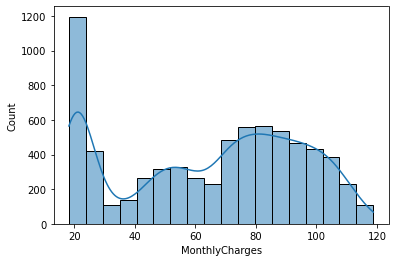

```python
sns.histplot(churn['MonthlyCharges'], kde=True)
```

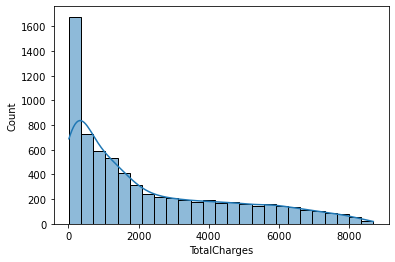

```python
sns.histplot(churn['TotalCharges'], kde=True)
```

A large group of customers generate small amount of revenue for the telecom company. This is evident from the above two charts

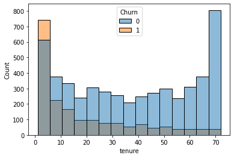

```python
sns.histplot(data=churn, x=churn['tenure'], hue=churn['Churn'])
```

If customers in the initial tenure are retained, then there is a higher probability that they will continue to use the services offered by the telecom company

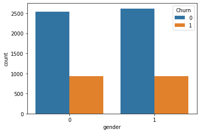

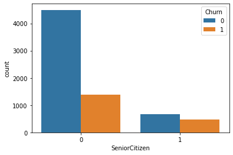

```python
feature = ['gender', 'SeniorCitizen']

for i in feature:
    sns.countplot(churn[i], hue=churn['Churn'])
    plt.show()
```

There is not much difference between the customers in terms of gender

And only a small number of users are senior citizens

```python
n_true = len(churn.loc[churn['Churn'] == 1])
n_false = len(churn.loc[churn['Churn'] == 0])
print("Number of churn cases     : {0} ({1:2.2f}%)".format(n_true, (n_true / (n_true + n_false)) * 100 ))
print("Number of retention cases : {0} ({1:2.2f}%)".format(n_false, (n_false / (n_true + n_false)) * 100))
```

```
Number of churn cases     : 1869 (26.58%)
Number of retention cases : 5163 (73.42%)
```

There is a churn opportunity of 26.58% for the telecom company

# 4. Data pre-processing: [ Score: 5 point ]

• Segregate predictors vs target attributes

• Check for target balancing and fix it if found imbalanced.

• Perform train-test split.

• Check if the train and test data have similar statistical characteristics when compared with original data.

```python
#Segregating predictors and target attributes

X = churn.drop('Churn',axis=1)
y = churn['Churn']


#Performing train-test split

X_train, X_test, y_train, y_test = train_test_split(X, y, test_size=0.3, random_state=1)

X_train.head()
```

|  | gender | SeniorCitizen | Partner | Dependents | tenure | PhoneService | MultipleLines | OnlineSecurity | OnlineBackup | DeviceProtection | ... | InternetService_DSL | InternetService_Fiber optic | InternetService_No | Contract_Month-to-month | Contract_One year | Contract_Two year | PaymentMethod_Bank transfer (automatic) | PaymentMethod_Credit card (automatic) | PaymentMethod_Electronic check | PaymentMethod_Mailed check |
| --- | --- | --- | --- | --- | --- | --- | --- | --- | --- | --- | --- | --- | --- | --- | --- | --- | --- | --- | --- | --- | --- |
| 1584 | 0 | 1 | 0 | 0 | 65 | 0 | 0 | 0 | 1 | 1 | ... | 1 | 0 | 0 | 0 | 0 | 1 | 1 | 0 | 0 | 0 |
| 1043 | 1 | 0 | 1 | 1 | 32 | 1 | 0 | 0 | 0 | 0 | ... | 0 | 1 | 0 | 1 | 0 | 0 | 1 | 0 | 0 | 0 |
| 1077 | 0 | 0 | 0 | 0 | 41 | 1 | 1 | 1 | 1 | 1 | ... | 0 | 1 | 0 | 1 | 0 | 0 | 1 | 0 | 0 | 0 |
| 2478 | 1 | 0 | 0 | 0 | 4 | 1 | 0 | 0 | 0 | 0 | ... | 1 | 0 | 0 | 1 | 0 | 0 | 0 | 0 | 0 | 1 |
| 6908 | 1 | 0 | 0 | 1 | 9 | 1 | 0 | 0 | 0 | 0 | ... | 1 | 0 | 0 | 1 | 0 | 0 | 0 | 0 | 1 | 0 |

5 rows × 26 columns

```python
print("{0:0.2f}% data is in training set".format((len(X_train)/len(churn.index)) * 100))
print("{0:0.2f}% data is in test set".format((len(X_test)/len(churn.index)) * 100))
```

```
69.99% data is in training set
30.01% data is in test set
```

```python
print("Original Churn Values       : {0} ({1:0.2f}%)".format(len(churn.loc[churn['Churn'] == 1]), (len(churn.loc[churn['Churn'] == 1])/len(churn.index)) * 100))
print("Original Retention Values   : {0} ({1:0.2f}%)".format(len(churn.loc[churn['Churn'] == 0]), (len(churn.loc[churn['Churn'] == 0])/len(churn.index)) * 100))
print("")
print("Training Churn Values       : {0} ({1:0.2f}%)".format(len(y_train[y_train[:] == 1]), (len(y_train[y_train[:] == 1])/len(y_train)) * 100))
print("Training Retention Values   : {0} ({1:0.2f}%)".format(len(y_train[y_train[:] == 0]), (len(y_train[y_train[:] == 0])/len(y_train)) * 100))
print("")
print("Test Churn Values           : {0} ({1:0.2f}%)".format(len(y_test[y_test[:] == 1]), (len(y_test[y_test[:] == 1])/len(y_test)) * 100))
print("Test Retention Values       : {0} ({1:0.2f}%)".format(len(y_test[y_test[:] == 0]), (len(y_test[y_test[:] == 0])/len(y_test)) * 100))
print("")
```

```
Original Churn Values       : 1869 (26.58%)
Original Retention Values   : 5163 (73.42%)

Training Churn Values       : 1314 (26.70%)
Training Retention Values   : 3608 (73.30%)

Test Churn Values           : 555 (26.30%)
Test Retention Values       : 1555 (73.70%)
```

The train and test data have similar statistical characteristics when compared with original data

# 5. Model training, testing and tuning: [ Score: 25 point ]

• Train and test all ensemble models taught in the learning module.

• Display the classification accuracies for train and test data.

• Apply all the possible tuning techniques to train the best model for the given data.

• Display and compare all the models designed with their train and test accuracies.

• Select the final best trained model along with your detailed comments for selecting this model.

• Pickle the selected model for future use.

```python
#Use of DecisionTreeClassifier method with criterion = 'gini'

dTree = DecisionTreeClassifier(criterion = 'gini', random_state=1)
dTree.fit(X_train, y_train)
```

```
DecisionTreeClassifier(random_state=1)
```

```python
#Prediction accuracies without pruning (Data is overfitted)

print(dTree.score(X_train, y_train))
print(dTree.score(X_test, y_test))
```

```
0.9979683055668428
0.7251184834123223
```

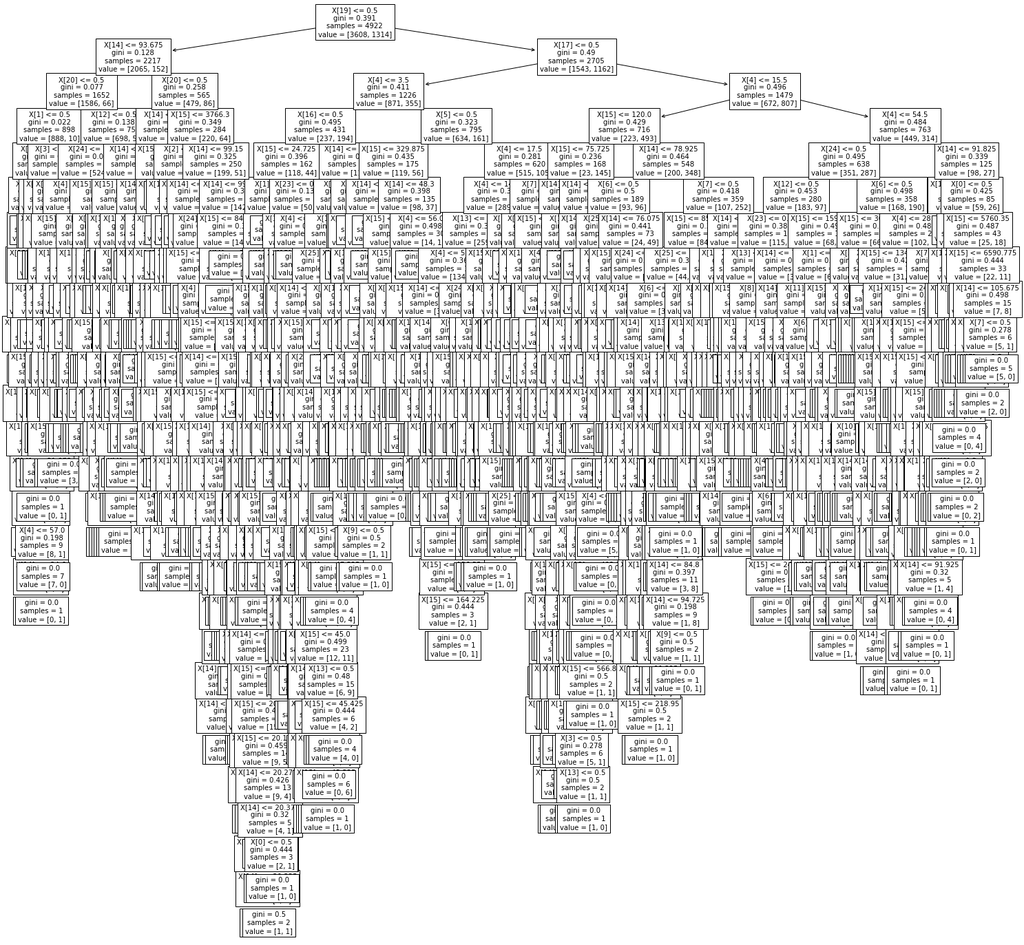

```python
#Visualisation of the decision tree

fig, ax = plt.subplots(figsize=(25, 25))
tree.plot_tree(dTree, fontsize=10)
plt.show()
```

```python
#Use of DecisionTreeClassifier method with criterion = 'gini'

#Pruning with max_depth = 4

dTreeR = DecisionTreeClassifier(criterion = 'gini', max_depth = 4, random_state=1)
dTreeR.fit(X_train, y_train)

#Prediction accuracies
print(dTreeR.score(X_train, y_train))
print(dTreeR.score(X_test, y_test))
```

```
0.7945956928078017
0.795734597156398
```

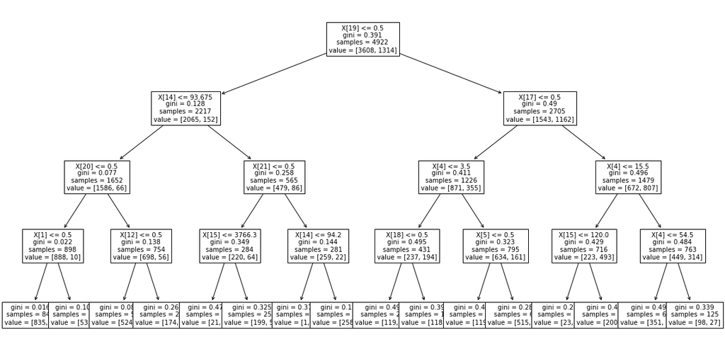

```python
#Visualisation of the decision tree, after pruning with max_depth = 4

fig, ax = plt.subplots(figsize=(20, 10))
tree.plot_tree(dTreeR, fontsize=10)
plt.show()
```

```python
# importance of features in the tree building ( The importance of a feature is computed as the
#(normalized) total reduction of the criterion brought by that feature. It is also known as the Gini importance )

print (pd.DataFrame(dTreeR.feature_importances_, columns = ["Imp"], index = X_train.columns))
```

```
                                              Imp
gender                                   0.000000
SeniorCitizen                            0.000375
Partner                                  0.000000
Dependents                               0.000000
tenure                                   0.178403
PhoneService                             0.010793
MultipleLines                            0.000000
OnlineSecurity                           0.000000
OnlineBackup                             0.000000
DeviceProtection                         0.000000
TechSupport                              0.000000
StreamingTV                              0.000000
StreamingMovies                          0.007209
PaperlessBilling                         0.000000
MonthlyCharges                           0.024870
TotalCharges                             0.026623
InternetService_DSL                      0.000000
InternetService_Fiber optic              0.153187
InternetService_No                       0.028824
Contract_Month-to-month                  0.553377
Contract_One year                        0.005693
Contract_Two year                        0.010645
PaymentMethod_Bank transfer (automatic)  0.000000
PaymentMethod_Credit card (automatic)    0.000000
PaymentMethod_Electronic check           0.000000
PaymentMethod_Mailed check               0.000000
```

Parameters such as Contract_Month-to-month, tenure and InternetService_Fiber optic have the maximum importance followed by the others

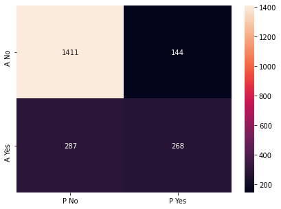

```python
#Confusion matrix

y_predict = dTreeR.predict(X_test)

cm = confusion_matrix(y_test, y_predict, labels=[0, 1])

df_cm = pd.DataFrame(cm, index = [i for i in ["A No","A Yes"]],
                  columns = [i for i in ["P No","P Yes"]])
plt.figure(figsize = (7,5))
sns.heatmap(df_cm, annot=True ,fmt='g')
```

Our aim is to create a machine learning model with maximum number of true positives / recall (churn maximum number of customers) and preferably high accuracy

In this case of DecisionTreeClassifier method with criterion = 'gini', the number of true positives is 268

```python
#Use of DecisionTreeClassifier method with criterion = 'entropy'

#Pruning with max_depth = 4

dTreeR = DecisionTreeClassifier(criterion = 'entropy', max_depth = 4, random_state=1)
dTreeR.fit(X_train, y_train)

#Prediction accuracies

print(dTreeR.score(X_train, y_train))
print(dTreeR.score(X_test, y_test))
```

```
0.7941893539211703
0.7962085308056872
```

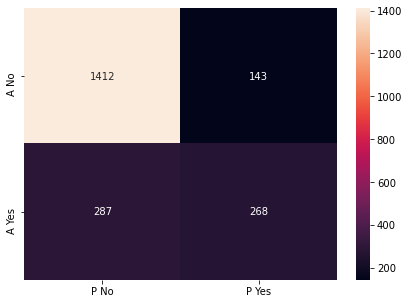

```python
#Confusion matrix

y_predict = dTreeR.predict(X_test)

cm = confusion_matrix(y_test, y_predict, labels=[0, 1])

df_cm = pd.DataFrame(cm, index = [i for i in ["A No","A Yes"]],
                  columns = [i for i in ["P No","P Yes"]])
plt.figure(figsize = (7,5))
sns.heatmap(df_cm, annot=True ,fmt='g')
```

There is no major difference between DecisionTreeClassifier method with criterion = 'entropy' and criterion = 'entropy'

```python
#Use of BaggingClassifier method with base_estimator=dTree and n_estimators=15

bgcl = BaggingClassifier(base_estimator=dTree, n_estimators=15,random_state=1)

bgcl = bgcl.fit(X_train, y_train)


#Prediction accuracies

print(bgcl.score(X_train, y_train))
print(bgcl.score(X_test , y_test))
```

```
0.9920763917106867
0.7611374407582938
```

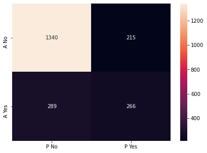

```python
#Confusion matrix

y_predict = bgcl.predict(X_test)

cm=confusion_matrix(y_test, y_predict,labels=[0, 1])

df_cm = pd.DataFrame(cm, index = [i for i in ["A No","A Yes"]],
                  columns = [i for i in ["P No","P Yes"]])
plt.figure(figsize = (7,5))
sns.heatmap(df_cm, annot=True ,fmt='g')
```

In BaggingClassifier method with base_estimator=dTree and n_estimators=15, the number of true positives is 266

```python
#Use of AdaBoostClassifier method with n_estimators=10

abcl = AdaBoostClassifier(n_estimators=10, random_state=1)
abcl = abcl.fit(X_train, y_train)


#Prediction accuracies

print(abcl.score(X_train, y_train))
print(abcl.score(X_test , y_test))
```

```
0.7939861844778545
0.7976303317535545
```

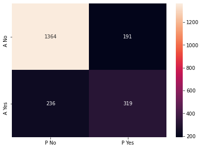

```python
#Confusion matrix

y_predict = abcl.predict(X_test)

cm=confusion_matrix(y_test, y_predict,labels=[0, 1])

df_cm = pd.DataFrame(cm, index = [i for i in ["A No","A Yes"]],
                  columns = [i for i in ["P No","P Yes"]])
plt.figure(figsize = (7,5))
sns.heatmap(df_cm, annot=True ,fmt='g')
```

In AdaBoostClassifier method with n_estimators=10, the number of true positives is 319

```python
#Use of GradientBoostingClassifier method with n_estimators = 50

gbcl = GradientBoostingClassifier(n_estimators = 50,random_state=1)
gbcl = gbcl.fit(X_train, y_train)


#Prediction accuracies

print(gbcl.score(X_train, y_train))
print(gbcl.score(X_test, y_test))
```

```
0.821007720438846
0.7995260663507109
```

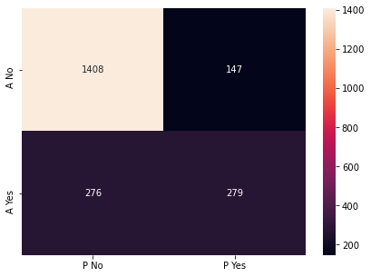

```python
#Confusion matrix

y_predict = gbcl.predict(X_test)

cm=confusion_matrix(y_test, y_predict,labels=[0, 1])

df_cm = pd.DataFrame(cm, index = [i for i in ["A No","A Yes"]],
                  columns = [i for i in ["P No","P Yes"]])
plt.figure(figsize = (7,5))
sns.heatmap(df_cm, annot=True ,fmt='g')
```

In GradientBoostingClassifier method with n_estimators=50, the number of true positives is 279

```python
#Use of RandomForestClassifier method with n_estimators = 15 and max_features=8

rfcl = RandomForestClassifier(n_estimators = 15, random_state=1,max_features=8)
rfcl = rfcl.fit(X_train, y_train)


#Prediction accuracies

print(rfcl.score(X_train, y_train))
print(rfcl.score(X_test, y_test))
```

```
0.9926859000406338
0.771090047393365
```

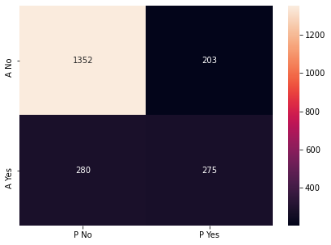

```python
#Confusion matrix

y_predict = rfcl.predict(X_test)

cm=confusion_matrix(y_test, y_predict,labels=[0, 1])

df_cm = pd.DataFrame(cm, index = [i for i in ["A No","A Yes"]],
                  columns = [i for i in ["P No","P Yes"]])
plt.figure(figsize = (7,5))
sns.heatmap(df_cm, annot=True ,fmt='g')
```

In RandomForestClassifier method with n_estimators = 15 and max_features=8, the number of true positives is 275

## Selection of the final best trained model

AdaBoostClassifier method with n_estimators=10 is the best trained model, as it has the highest number of true positives with a recall of 57.48%

Also, it has one of the best prediction accuracies with test data set at 79.76%

GradientBoostingClassifier method with n_estimators = 50 has a prediction accuracy of 79.95% with test data but the recall is just 50.27%

```python
#Creating pickle the selected model for future use

#AdaBoostClassifier method with n_estimators=10

abcl = AdaBoostClassifier(n_estimators=10, random_state=1)
abcl = abcl.fit(X_train, y_train)


with open('AdaBoostClassifier.pickle', 'wb') as dump_var:
    pickle.dump(abcl, dump_var)
```

```python
#Using pickle file instead of AdaBoostClassifier

pickle_in = open('AdaBoostClassifier.pickle', 'rb')
pickle_abcl = pickle.load(pickle_in)


#Prediction accuracies using the pickle file

print(pickle_abcl.score(X_train, y_train))
print(pickle_abcl.score(X_test, y_test))
```

```
0.7939861844778545
0.7976303317535545
```

# 6. Conclusion and improvisation: [ Score: 5 point ]

• Write your conclusion on the results.

• Detailed suggestions or improvements or on quality, quantity, variety, velocity, veracity etc. on the data points collected by the telecom operator to perform a better data analysis in future.

## Conclusion :

AdaBoostClassifier method with n_estimators=10 is the best trained model, as it has the highest number of true positives with a recall of 57.48%

Also, it has one of the best prediction accuracies with test data set at 79.76%

GradientBoostingClassifier method with n_estimators = 50 has a prediction accuracy of 79.95% with test data but the recall is just 50.27%

## Improvisation :

1. Parameters such as age and city would have helped in better prediction, as they have high importance considering telecom industry
2. The quantity of data could have been higher (over 50,000 rows), along with the above metioned parameters
3. Generally men use more telecom services than women. But in this dataset, both genders show similar characteristics due to which, gender as a feature had no importance. A larger and realistic data could have improved prediction accuracy.